# Data processing tutorial

This will be a brief tutorial on how to start your data analysis. We will consider the following dataset, that I found by poking around on the Bureau of Economic Analysis website.

```r
setwd("/media/Storage/Dropbox/Desktop")
DE_gdp <- read.csv("gdp_DE.csv")
head(DE_gdp)
```

|  | GeoFIPS | GeoName | Region | TableName | ComponentName | Unit | IndustryId | IndustryClassification | Description | X1997 | X1998 | X1999 | X2000 | X2001 | X2002 | X2003 | X2004 | X2005 | X2006 | X2007 | X2008 | X2009 | X2010 | X2011 | X2012 | X2013 | X2014 | X2015 | X2016 | … |
| --- | --- | --- | --- | --- | --- | --- | --- | --- | --- | --- | --- | --- | --- | --- | --- | --- | --- | --- | --- | --- | --- | --- | --- | --- | --- | --- | --- | --- | --- | --- |
| 1 | 10000 | Delaware | 2 | SAGDP2N | Gross domestic product (GDP) by state | Millions of current dollars | 1 | ... | All industry total | 32967.7 | 36783.2 | 40363.6 | 43389.4 | 46448.3 | 45757.9 | 47761.6 | 51449.4 | 52154.1 | 55067.4 | 56278.5 | 54787.5 | 56871.2 | 57447.4 | 60357.4 | 61975.8 | 60666.1 | 67178.9 | 70917.7 | 70484.1 | … |
| 2 | 10000 | Delaware | 2 | SAGDP2N | Gross domestic product (GDP) by state | Millions of current dollars | 2 | ... | Private industries | 29897.1 | 33520.3 | 36877.7 | 39669.2 | 42507.7 | 41390.2 | 43250.0 | 46740.2 | 47046.6 | 49906.5 | 50707.2 | 48914.3 | 50690.9 | 51273.3 | 54015.8 | 55617.1 | 54234 | 60758.2 | 64266.0 | 63711.0 | … |
| 3 | 10000 | Delaware | 2 | SAGDP2N | Gross domestic product (GDP) by state | Millions of current dollars | 3 | 11 | Agriculture, forestry, fishing, and hunting | 194.7 | 227.0 | 215.0 | 227.3 | 287.3 | 167.6 | 266.1 | 396.4 | 411.8 | 325.2 | 337.8 | 334.9 | 398.0 | 379.6 | 371.0 | 417.0 | 581.3 | 652.1 | 484.2 | 456.8 | … |
| 4 | 10000 | Delaware | 2 | SAGDP2N | Gross domestic product (GDP) by state | Millions of current dollars | 4 | 111-112 | Farms | 174.0 | 205.2 | 191.7 | 205.8 | 271.6 | 152.8 | 247.4 | 375.3 | 390.9 | 303.5 | 319.5 | 315.4 | 377.7 | 355.4 | 342.4 | 386.4 | 550.8 | 618.1 | 447.2 | 419.4 | … |
| 5 | 10000 | Delaware | 2 | SAGDP2N | Gross domestic product (GDP) by state | Millions of current dollars | 5 | 113-115 | Forestry, fishing, and related activities | 20.7 | 21.8 | 23.3 | 21.6 | 15.7 | 14.8 | 18.6 | 21.1 | 20.8 | 21.8 | 18.4 | 19.4 | 20.3 | 24.3 | 28.5 | 30.6 | 30.6 | 34.1 | 37.0 | 37.4 | … |
| 6 | 10000 | Delaware | 2 | SAGDP2N | Gross domestic product (GDP) by state | Millions of current dollars | 6 | 21 | Mining, quarrying, and oil and gas extraction | 11.8 | 11.2 | 11.3 | 11.9 | 10.3 | 9.1 | 5.0 | 4.9 | 1.8 | 1.4 | 0.5 | 0.8 | 0.7 | 1.3 | 0.1 | 0.2 | 2.8 | 3.0 | 3.6 | 3.8 | … |

We note that the dataset is a sub-part of a dataset on the GDP by state in Millions of Dollars. Particularly, we see that the GPD is given statewide and by industry, year by year between 1997 until 2017. This seems like a relatively good dataset without too much work to process.

Let’s suppose that we want to fit a linear model for which industries had what effect on the change of total GPD statewide in this decade.

Let’s first trim down the data into the useful parts, and then form a dataframe with the observed response variables and the explanatory variables. We don’t need the GeoFIPs, GeoName, Region, TableName, ComponentName, or Unit columns in the data:

```r
DE_gdp <- DE_gdp[,-c(1:6)]
head(DE_gdp)
```

|  | IndustryId | IndustryClassification | Description | X1997 | X1998 | X1999 | X2000 | X2001 | X2002 | X2003 | X2004 | X2005 | X2006 | X2007 | X2008 | X2009 | X2010 | X2011 | X2012 | X2013 | X2014 | X2015 | X2016 | X2017 |
| --- | --- | --- | --- | --- | --- | --- | --- | --- | --- | --- | --- | --- | --- | --- | --- | --- | --- | --- | --- | --- | --- | --- | --- | --- |
| 1 | 1 | ... | All industry total | 32967.7 | 36783.2 | 40363.6 | 43389.4 | 46448.3 | 45757.9 | 47761.6 | 51449.4 | 52154.1 | 55067.4 | 56278.5 | 54787.5 | 56871.2 | 57447.4 | 60357.4 | 61975.8 | 60666.1 | 67178.9 | 70917.7 | 70484.1 | 72461.3 |
| 2 | 2 | ... | Private industries | 29897.1 | 33520.3 | 36877.7 | 39669.2 | 42507.7 | 41390.2 | 43250.0 | 46740.2 | 47046.6 | 49906.5 | 50707.2 | 48914.3 | 50690.9 | 51273.3 | 54015.8 | 55617.1 | 54234 | 60758.2 | 64266.0 | 63711.0 | 65480.2 |
| 3 | 3 | 11 | Agriculture, forestry, fishing, and hunting | 194.7 | 227.0 | 215.0 | 227.3 | 287.3 | 167.6 | 266.1 | 396.4 | 411.8 | 325.2 | 337.8 | 334.9 | 398.0 | 379.6 | 371.0 | 417.0 | 581.3 | 652.1 | 484.2 | 456.8 | (D) |
| 4 | 4 | 111-112 | Farms | 174.0 | 205.2 | 191.7 | 205.8 | 271.6 | 152.8 | 247.4 | 375.3 | 390.9 | 303.5 | 319.5 | 315.4 | 377.7 | 355.4 | 342.4 | 386.4 | 550.8 | 618.1 | 447.2 | 419.4 | (NA) |
| 5 | 5 | 113-115 | Forestry, fishing, and related activities | 20.7 | 21.8 | 23.3 | 21.6 | 15.7 | 14.8 | 18.6 | 21.1 | 20.8 | 21.8 | 18.4 | 19.4 | 20.3 | 24.3 | 28.5 | 30.6 | 30.6 | 34.1 | 37.0 | 37.4 | (NA) |
| 6 | 6 | 21 | Mining, quarrying, and oil and gas extraction | 11.8 | 11.2 | 11.3 | 11.9 | 10.3 | 9.1 | 5.0 | 4.9 | 1.8 | 1.4 | 0.5 | 0.8 | 0.7 | 1.3 | 0.1 | 0.2 | 2.8 | 3.0 | 3.6 | 3.8 | (D) |

Now, lets suppose the response variable will be the percent change in GPD from year to year. Specifically, we will construct a response variable vector $\mathbf{Y}$ as follows:

```r
Y_obs <- DE_gdp[1,]
Y_obs <- Y_obs[-c(1:3)]
Y_obs
```

|  | X1997 | X1998 | X1999 | X2000 | X2001 | X2002 | X2003 | X2004 | X2005 | X2006 | X2007 | X2008 | X2009 | X2010 | X2011 | X2012 | X2013 | X2014 | X2015 | X2016 | X2017 |
| --- | --- | --- | --- | --- | --- | --- | --- | --- | --- | --- | --- | --- | --- | --- | --- | --- | --- | --- | --- | --- | --- |
| 1 | 32967.7 | 36783.2 | 40363.6 | 43389.4 | 46448.3 | 45757.9 | 47761.6 | 51449.4 | 52154.1 | 55067.4 | 56278.5 | 54787.5 | 56871.2 | 57447.4 | 60357.4 | 61975.8 | 60666.1 | 67178.9 | 70917.7 | 70484.1 | 72461.3 |

The resulting vector is a vector of the year by year GDP for all industry in Delaware. Now, we suppose we want to find the percent change year by year. Let’s first convert the observations of 1998-2017 and 1997-2016 to numeric,

```r
Y_forward <- as.numeric(Y_obs[-1])
Y_forward
```

```
##  [1] 36783.2 40363.6 43389.4 46448.3 45757.9 47761.6 51449.4 52154.1
##  [9] 55067.4 56278.5 54787.5 56871.2 57447.4 60357.4 61975.8    71.0
## [17] 67178.9 70917.7 70484.1    32.0
```

```r
Y_backward <- as.numeric(Y_obs[-length(Y_obs)])
Y_backward
```

```
##  [1] 32967.7 36783.2 40363.6 43389.4 46448.3 45757.9 47761.6 51449.4
##  [9] 52154.1 55067.4 56278.5 54787.5 56871.2 57447.4 60357.4 61975.8
## [17]    71.0 67178.9 70917.7 70484.1
```

We note that there is a very unusual conversion, that gave faulty values in the Y_forward and Y_backward vectors. In this case, we over-write the spurious values directly,

```r
Y_forward[16] <- 60666.1
Y_forward[length(Y_forward)] <- 72461.3
Y_forward
```

```
##  [1] 36783.2 40363.6 43389.4 46448.3 45757.9 47761.6 51449.4 52154.1
##  [9] 55067.4 56278.5 54787.5 56871.2 57447.4 60357.4 61975.8 60666.1
## [17] 67178.9 70917.7 70484.1 72461.3
```

```r
Y_backward[17] <- 60666.1
Y_backward
```

```
##  [1] 32967.7 36783.2 40363.6 43389.4 46448.3 45757.9 47761.6 51449.4
##  [9] 52154.1 55067.4 56278.5 54787.5 56871.2 57447.4 60357.4 61975.8
## [17] 60666.1 67178.9 70917.7 70484.1
```

With the spurious values fixed, we compute the differences,

```r
Y_diff <- Y_forward - Y_backward
Y_diff
```

```
##  [1]  3815.5  3580.4  3025.8  3058.9  -690.4  2003.7  3687.8   704.7
##  [9]  2913.3  1211.1 -1491.0  2083.7   576.2  2910.0  1618.4 -1309.7
## [17]  6512.8  3738.8  -433.6  1977.2
```

and we create the vector Y_diff of the year-by-year changes in GPD Now, if we want to compute the percent difference, we can do this as follows:

```r
Y_percent_diff <- Y_diff / as.numeric(Y_backward)
Y_percent_diff
```

```
##  [1]  0.115734492  0.097337915  0.074963581  0.070498785 -0.014863838
##  [6]  0.043789160  0.077212656  0.013696953  0.055859463  0.021993049
## [11] -0.026493243  0.038032398  0.010131666  0.050655034  0.026813614
## [16] -0.021132442  0.107354849  0.055654380 -0.006114129  0.028051717
```

We thus have finally a vector of the percent change in statewide GPD per year for the years between 1997 and 2017. Now, we consider the explanatory variables. Let’s go through and process the data to remove unintersting and bad data. To begin with, we notice

```r
head(DE_gdp)
```

|  | IndustryId | IndustryClassification | Description | X1997 | X1998 | X1999 | X2000 | X2001 | X2002 | X2003 | X2004 | X2005 | X2006 | X2007 | X2008 | X2009 | X2010 | X2011 | X2012 | X2013 | X2014 | X2015 | X2016 | X2017 |
| --- | --- | --- | --- | --- | --- | --- | --- | --- | --- | --- | --- | --- | --- | --- | --- | --- | --- | --- | --- | --- | --- | --- | --- | --- |
| 1 | 1 | ... | All industry total | 32967.7 | 36783.2 | 40363.6 | 43389.4 | 46448.3 | 45757.9 | 47761.6 | 51449.4 | 52154.1 | 55067.4 | 56278.5 | 54787.5 | 56871.2 | 57447.4 | 60357.4 | 61975.8 | 60666.1 | 67178.9 | 70917.7 | 70484.1 | 72461.3 |
| 2 | 2 | ... | Private industries | 29897.1 | 33520.3 | 36877.7 | 39669.2 | 42507.7 | 41390.2 | 43250.0 | 46740.2 | 47046.6 | 49906.5 | 50707.2 | 48914.3 | 50690.9 | 51273.3 | 54015.8 | 55617.1 | 54234 | 60758.2 | 64266.0 | 63711.0 | 65480.2 |
| 3 | 3 | 11 | Agriculture, forestry, fishing, and hunting | 194.7 | 227.0 | 215.0 | 227.3 | 287.3 | 167.6 | 266.1 | 396.4 | 411.8 | 325.2 | 337.8 | 334.9 | 398.0 | 379.6 | 371.0 | 417.0 | 581.3 | 652.1 | 484.2 | 456.8 | (D) |
| 4 | 4 | 111-112 | Farms | 174.0 | 205.2 | 191.7 | 205.8 | 271.6 | 152.8 | 247.4 | 375.3 | 390.9 | 303.5 | 319.5 | 315.4 | 377.7 | 355.4 | 342.4 | 386.4 | 550.8 | 618.1 | 447.2 | 419.4 | (NA) |
| 5 | 5 | 113-115 | Forestry, fishing, and related activities | 20.7 | 21.8 | 23.3 | 21.6 | 15.7 | 14.8 | 18.6 | 21.1 | 20.8 | 21.8 | 18.4 | 19.4 | 20.3 | 24.3 | 28.5 | 30.6 | 30.6 | 34.1 | 37.0 | 37.4 | (NA) |
| 6 | 6 | 21 | Mining, quarrying, and oil and gas extraction | 11.8 | 11.2 | 11.3 | 11.9 | 10.3 | 9.1 | 5.0 | 4.9 | 1.8 | 1.4 | 0.5 | 0.8 | 0.7 | 1.3 | 0.1 | 0.2 | 2.8 | 3.0 | 3.6 | 3.8 | (D) |

that we can remove the first two rows outright.

```r
DE_gdp <- DE_gdp[-c(1:2),]
head(DE_gdp)
```

|  | IndustryId | IndustryClassification | Description | X1997 | X1998 | X1999 | X2000 | X2001 | X2002 | X2003 | X2004 | X2005 | X2006 | X2007 | X2008 | X2009 | X2010 | X2011 | X2012 | X2013 | X2014 | X2015 | X2016 | X2017 |
| --- | --- | --- | --- | --- | --- | --- | --- | --- | --- | --- | --- | --- | --- | --- | --- | --- | --- | --- | --- | --- | --- | --- | --- | --- |
| 3 | 3 | 11 | Agriculture, forestry, fishing, and hunting | 194.7 | 227.0 | 215.0 | 227.3 | 287.3 | 167.6 | 266.1 | 396.4 | 411.8 | 325.2 | 337.8 | 334.9 | 398.0 | 379.6 | 371.0 | 417.0 | 581.3 | 652.1 | 484.2 | 456.8 | (D) |
| 4 | 4 | 111-112 | Farms | 174.0 | 205.2 | 191.7 | 205.8 | 271.6 | 152.8 | 247.4 | 375.3 | 390.9 | 303.5 | 319.5 | 315.4 | 377.7 | 355.4 | 342.4 | 386.4 | 550.8 | 618.1 | 447.2 | 419.4 | (NA) |
| 5 | 5 | 113-115 | Forestry, fishing, and related activities | 20.7 | 21.8 | 23.3 | 21.6 | 15.7 | 14.8 | 18.6 | 21.1 | 20.8 | 21.8 | 18.4 | 19.4 | 20.3 | 24.3 | 28.5 | 30.6 | 30.6 | 34.1 | 37.0 | 37.4 | (NA) |
| 6 | 6 | 21 | Mining, quarrying, and oil and gas extraction | 11.8 | 11.2 | 11.3 | 11.9 | 10.3 | 9.1 | 5.0 | 4.9 | 1.8 | 1.4 | 0.5 | 0.8 | 0.7 | 1.3 | 0.1 | 0.2 | 2.8 | 3.0 | 3.6 | 3.8 | (D) |
| 7 | 7 | 211 | Oil and gas extraction | 3.2 | 2.9 | 3.2 | 3.7 | 0.4 | 0.7 | 0.8 | 1.2 | 1.0 | 0.8 | 0.0 | 0.0 | 0.0 | 1.1 | 0.0 | 0.0 | 0 | 0.0 | 0.0 | 0.0 | (NA) |
| 8 | 8 | 212 | Mining (except oil and gas) | 6.9 | 6.7 | 6.7 | 6.6 | 9.9 | 8.1 | 4.0 | 3.6 | 0.6 | 0.4 | 0.4 | 0.6 | 0.7 | 0.1 | 0.1 | 0.2 | 2.8 | 3.0 | 3.6 | 3.8 | (NA) |

Now, we want to see what are the particular industries in Delaware,

```r
DE_gdp[,3]
```

```
##  [1]   Agriculture, forestry, fishing, and hunting
##  [2]    Farms
##  [3]    Forestry, fishing, and related activities
##  [4]   Mining, quarrying, and oil and gas extraction
##  [5]    Oil and gas extraction
##  [6]    Mining (except oil and gas)
##  [7]    Support activities for mining
##  [8]   Utilities
##  [9]   Construction
## [10]   Manufacturing
## [11]    Durable goods manufacturing
## [12]     Wood product manufacturing
## [13]     Nonmetallic mineral product manufacturing
## [14]     Primary metal manufacturing
## [15]     Fabricated metal product manufacturing
```

[output cut: 79 more lines]

In particular, we note that many of the sub-categories are classified under larger umbrella categories. In this case, we will only select a few of the large categories for our analysis, minding the number of degrees of freedom in the data set

```r
length(Y_percent_diff)
```

```
## [1] 20
```

Correspondingly, we extract a sub-array based on these variables alone:

```r
exp_vars_df <- DE_gdp[c(1, 4, 8, 9, 32, 33, 34, 43, 48, 57, 66, 77, 81),-c(1,2)]
row.names(exp_vars_df) <- c()
exp_vars_df <- data.frame(exp_vars_df)
summary(exp_vars_df)
```

```
##                                                      Description
##     Accommodation and food services                        :1
##    Agriculture, forestry, fishing, and hunting             :1
##    Construction                                            :1
##    Educational services, health care, and social assistance:1
##    Finance, insurance, real estate, rental, and leasing    :1
##    Information                                             :1
##  (Other)                                                   :7
##      X1997             X1998             X1999             X2000
##  Min.   :   11.8   Min.   :   11.2   Min.   :   11.3   Min.   :   11.9
##  1st Qu.:  592.4   1st Qu.:  573.6   1st Qu.:  622.1   1st Qu.:  603.9
##  Median : 1151.0   Median : 1217.1   Median : 1281.2   Median : 1420.8
##  Mean   : 2176.2   Mean   : 2455.0   Mean   : 2702.0   Mean   : 2936.0
##  3rd Qu.: 1741.6   3rd Qu.: 1885.9   3rd Qu.: 1988.1   3rd Qu.: 2154.0
##  Max.   :13113.1   Max.   :15310.8   Max.   :17578.4   Max.   :19529.2
##
##      X2001             X2002             X2003             X2004
##  Min.   :   10.3   Min.   :    9.1   Min.   :    5.0   Min.   :    4.9
##  1st Qu.:  623.8   1st Qu.:  611.3   1st Qu.:  621.9   1st Qu.:  726.3
##  Median : 1406.4   Median : 1441.4   Median : 1701.8   Median : 1917.4
##  Mean   : 3177.2   Mean   : 3178.2   Mean   : 3316.2   Mean   : 3510.1
##  3rd Qu.: 2340.9   3rd Qu.: 2503.2   3rd Qu.: 2743.9   3rd Qu.: 2984.1
##  Max.   :22138.9   Max.   :21310.3   Max.   :21877.0   Max.   :22258.4
##
##      X2005             X2006             X2007             X2008
##  Min.   :    1.8   Min.   :    1.4   Min.   :    0.5   Min.   :    0.8
##  1st Qu.:  722.0   1st Qu.:  813.3   1st Qu.:  837.1   1st Qu.:  822.7
##  Median : 2023.1   Median : 2329.2   Median : 2293.1   Median : 2252.3
##  Mean   : 3567.5   Mean   : 3757.9   Mean   : 3820.5   Mean   : 3770.6
##  3rd Qu.: 3185.4   3rd Qu.: 3412.5   3rd Qu.: 3619.9   3rd Qu.: 3973.9
##  Max.   :21803.6   Max.   :23066.3   Max.   :23301.5   Max.   :21545.9
##
##      X2009             X2010             X2011             X2012
##  Min.   :    0.7   Min.   :    1.3   Min.   :    0.1   Min.   :    0.2
##  1st Qu.:  880.5   1st Qu.:  958.4   1st Qu.:  917.5   1st Qu.:  868.9
##  Median : 1847.8   Median : 1718.0   Median : 1916.8   Median : 2012.9
##  Mean   : 3938.2   Mean   : 3999.2   Mean   : 4216.5   Mean   : 4369.4
##  3rd Qu.: 4206.4   3rd Qu.: 4310.5   3rd Qu.: 4560.8   3rd Qu.: 4749.0
##  Max.   :24225.4   Max.   :24191.6   Max.   :25602.1   Max.   :26529.7
##
##      X2013       X2014             X2015             X2016
##  1204.7 :1   Min.   :    3.0   Min.   :    3.6   Min.   :    3.8
##  1611.7 :1   1st Qu.:  995.4   1st Qu.: 1099.2   1st Qu.: 1079.1
##  1854.9 :1   Median : 2080.5   Median : 2276.3   Median : 2284.4
##  2.8    :1   Mean   : 4755.7   Mean   : 4979.0   Mean   : 5009.1
##  2282.3 :1   3rd Qu.: 5173.4   3rd Qu.: 5412.0   3rd Qu.: 5603.3
##  24866.2:1   Max.   :30221.7   Max.   :32444.6   Max.   :32353.7
##  (Other):7
##      X2017
##  (D)    :2
##  1047   :1
##  1129.9 :1
##  1233   :1
##  1456.8 :1
##  1932.4 :1
##  (Other):6
```

We have *almost* constructed a dataframe that will be useful for the analysis. Note the columns 2013 and 2017,

```r
exp_vars_df$X2013
```

```
##  [1] 581.3   2.8     880.8   1854.9  2282.3  2564    927     1611.7
##  [9] 24866.2 7332.5  4895.7  1204.7  6432.1
## 91 Levels:  (L) 0 1.6 104 1040.4 1092.4 1186.8 1204.7 121.4 ... 9909.5
```

```r
exp_vars_df$X2017
```

```
##  [1] (D)     (D)     1047    2700.9  1932.4  2711.6  1129.9  1233
##  [9] 33108.5 8234.9  5791.9  1456.8  6981.1
## 34 Levels:  (D) (NA) 1014.1 10389.1 1047 1129.9 1233 1274.2 ... 8234.9
```

It appears that these are both coded as factor vectors, due to missing data. Therefore, we will investigate which are the offending lines. In this case, the data is small enough through our processing to do this by inspection

```r
exp_vars_df$X2013
```

```
##  [1] 581.3   2.8     880.8   1854.9  2282.3  2564    927     1611.7
##  [9] 24866.2 7332.5  4895.7  1204.7  6432.1
## 91 Levels:  (L) 0 1.6 104 1040.4 1092.4 1186.8 1204.7 121.4 ... 9909.5
```

It appears in the case of year 2013, there was just a read error, and we can simply convert to character and back to numeric.

```r
exp_vars_df$X2013 <- as.character(exp_vars_df$X2013)
exp_vars_df$X2013 <- as.numeric(exp_vars_df$X2013)
exp_vars_df$X2013
```

```
##  [1]   581.3     2.8   880.8  1854.9  2282.3  2564.0   927.0  1611.7
##  [9] 24866.2  7332.5  4895.7  1204.7  6432.1
```

In the case the year 2017,

```r
exp_vars_df$X2017
```

```
##  [1] (D)     (D)     1047    2700.9  1932.4  2711.6  1129.9  1233
##  [9] 33108.5 8234.9  5791.9  1456.8  6981.1
## 34 Levels:  (D) (NA) 1014.1 10389.1 1047 1129.9 1233 1274.2 ... 8234.9
```

it appears that the first two entries are not available. In this context, rather than dropping the entire first two rows, we will do without the observation in 2017.

Particularly, we re-write dataframe as follows:

```r
exp_vars_df$X2017 <- c()
summary(exp_vars_df)
```

```
##                                                      Description
##     Accommodation and food services                        :1
##    Agriculture, forestry, fishing, and hunting             :1
##    Construction                                            :1
##    Educational services, health care, and social assistance:1
##    Finance, insurance, real estate, rental, and leasing    :1
##    Information                                             :1
##  (Other)                                                   :7
##      X1997             X1998             X1999             X2000
##  Min.   :   11.8   Min.   :   11.2   Min.   :   11.3   Min.   :   11.9
##  1st Qu.:  592.4   1st Qu.:  573.6   1st Qu.:  622.1   1st Qu.:  603.9
##  Median : 1151.0   Median : 1217.1   Median : 1281.2   Median : 1420.8
##  Mean   : 2176.2   Mean   : 2455.0   Mean   : 2702.0   Mean   : 2936.0
##  3rd Qu.: 1741.6   3rd Qu.: 1885.9   3rd Qu.: 1988.1   3rd Qu.: 2154.0
##  Max.   :13113.1   Max.   :15310.8   Max.   :17578.4   Max.   :19529.2
##
##      X2001             X2002             X2003             X2004
##  Min.   :   10.3   Min.   :    9.1   Min.   :    5.0   Min.   :    4.9
##  1st Qu.:  623.8   1st Qu.:  611.3   1st Qu.:  621.9   1st Qu.:  726.3
##  Median : 1406.4   Median : 1441.4   Median : 1701.8   Median : 1917.4
##  Mean   : 3177.2   Mean   : 3178.2   Mean   : 3316.2   Mean   : 3510.1
##  3rd Qu.: 2340.9   3rd Qu.: 2503.2   3rd Qu.: 2743.9   3rd Qu.: 2984.1
##  Max.   :22138.9   Max.   :21310.3   Max.   :21877.0   Max.   :22258.4
##
##      X2005             X2006             X2007             X2008
##  Min.   :    1.8   Min.   :    1.4   Min.   :    0.5   Min.   :    0.8
##  1st Qu.:  722.0   1st Qu.:  813.3   1st Qu.:  837.1   1st Qu.:  822.7
##  Median : 2023.1   Median : 2329.2   Median : 2293.1   Median : 2252.3
##  Mean   : 3567.5   Mean   : 3757.9   Mean   : 3820.5   Mean   : 3770.6
##  3rd Qu.: 3185.4   3rd Qu.: 3412.5   3rd Qu.: 3619.9   3rd Qu.: 3973.9
##  Max.   :21803.6   Max.   :23066.3   Max.   :23301.5   Max.   :21545.9
##
##      X2009             X2010             X2011             X2012
##  Min.   :    0.7   Min.   :    1.3   Min.   :    0.1   Min.   :    0.2
##  1st Qu.:  880.5   1st Qu.:  958.4   1st Qu.:  917.5   1st Qu.:  868.9
##  Median : 1847.8   Median : 1718.0   Median : 1916.8   Median : 2012.9
##  Mean   : 3938.2   Mean   : 3999.2   Mean   : 4216.5   Mean   : 4369.4
##  3rd Qu.: 4206.4   3rd Qu.: 4310.5   3rd Qu.: 4560.8   3rd Qu.: 4749.0
##  Max.   :24225.4   Max.   :24191.6   Max.   :25602.1   Max.   :26529.7
##
##      X2013             X2014             X2015             X2016
##  Min.   :    2.8   Min.   :    3.0   Min.   :    3.6   Min.   :    3.8
##  1st Qu.:  927.0   1st Qu.:  995.4   1st Qu.: 1099.2   1st Qu.: 1079.1
##  Median : 1854.9   Median : 2080.5   Median : 2276.3   Median : 2284.4
##  Mean   : 4264.3   Mean   : 4755.7   Mean   : 4979.0   Mean   : 5009.1
##  3rd Qu.: 4895.7   3rd Qu.: 5173.4   3rd Qu.: 5412.0   3rd Qu.: 5603.3
##  Max.   :24866.2   Max.   :30221.7   Max.   :32444.6   Max.   :32353.7
##
```

and we are left with clean working data for the years between 1997 and 2016.

Let’s now suppose that we want to examine the following relationship:

“How does a percentage change in GPD for a given industrial sector correspond to the percent change in GPD statewide in the years 1997 - 2016?”

We will want to re-fit firstly the observations vector to be in terms of these years:

```r
Y_percent_diff <- Y_percent_diff[-length(Y_percent_diff)]
Y_percent_diff
```

```
##  [1]  0.115734492  0.097337915  0.074963581  0.070498785 -0.014863838
##  [6]  0.043789160  0.077212656  0.013696953  0.055859463  0.021993049
## [11] -0.026493243  0.038032398  0.010131666  0.050655034  0.026813614
## [16] -0.021132442  0.107354849  0.055654380 -0.006114129
```

removing the last entry for year 2017.

Now, we compute the percent change for each industry year by year,

```r
exp_vars_df_forward <- exp_vars_df[,-c(1,2)]
exp_vars_df_forward
```

| X1998 | X1999 | X2000 | X2001 | X2002 | X2003 | X2004 | X2005 | X2006 | X2007 | X2008 | X2009 | X2010 | X2011 | X2012 | X2013 | X2014 | X2015 | X2016 |
| --- | --- | --- | --- | --- | --- | --- | --- | --- | --- | --- | --- | --- | --- | --- | --- | --- | --- | --- |
| 227.0 | 215.0 | 227.3 | 287.3 | 167.6 | 266.1 | 396.4 | 411.8 | 325.2 | 337.8 | 334.9 | 398.0 | 379.6 | 371.0 | 417.0 | 581.3 | 652.1 | 484.2 | 456.8 |
| 11.2 | 11.3 | 11.9 | 10.3 | 9.1 | 5.0 | 4.9 | 1.8 | 1.4 | 0.5 | 0.8 | 0.7 | 1.3 | 0.1 | 0.2 | 2.8 | 3.0 | 3.6 | 3.8 |
| 573.6 | 622.1 | 569.4 | 578.5 | 611.3 | 606.9 | 656.1 | 633.2 | 813.3 | 837.1 | 822.7 | 880.5 | 958.4 | 917.5 | 868.9 | 880.8 | 995.4 | 1035.4 | 1033.6 |
| 1371.1 | 1551.4 | 1626.4 | 1620.8 | 1664.6 | 1753.7 | 2106.9 | 2351.5 | 2500.1 | 2325.7 | 2252.3 | 1847.8 | 1588.9 | 1706.8 | 1727.2 | 1854.9 | 2080.5 | 2378.5 | 2530.0 |
| 1217.1 | 1281.2 | 1420.8 | 1406.4 | 1441.4 | 1701.8 | 1917.4 | 2023.1 | 2329.2 | 2293.1 | 2287.3 | 2146.1 | 2217.2 | 2273.7 | 2298.3 | 2282.3 | 2389.7 | 2276.3 | 2284.4 |
| 1805.6 | 1917.4 | 1989.6 | 1891.9 | 2005.7 | 2149.0 | 2294.4 | 2391.1 | 2459.4 | 2470.8 | 2366.9 | 2312.0 | 2351.2 | 2401.3 | 2474.3 | 2564.0 | 2554.7 | 2590.8 | 2651.8 |
| 526.9 | 567.7 | 603.9 | 623.8 | 606.2 | 621.9 | 726.3 | 722.0 | 768.1 | 760.7 | 772.5 | 744.0 | 751.8 | 801.8 | 853.0 | 927.0 | 994.9 | 1099.2 | 1079.1 |
| 872.2 | 834.2 | 838.5 | 894.8 | 998.5 | 974.4 | 1084.2 | 1040.8 | 1025.2 | 1086.8 | 1275.1 | 1327.4 | 1718.0 | 1916.8 | 2012.9 | 1611.7 | 1353.9 | 1293.9 | 1346.1 |
| 15310.8 | 17578.4 | 19529.2 | 22138.9 | 21310.3 | 21877.0 | 22258.4 | 21803.6 | 23066.3 | 23301.5 | 21545.9 | 24225.4 | 24191.6 | 25602.1 | 26529.7 | 24866.2 | 30221.7 | 32444.6 | 32353.7 |
| 4075.5 | 4231.9 | 4553.0 | 4643.5 | 4690.2 | 4897.4 | 5407.0 | 5645.1 | 5891.6 | 5998.6 | 6421.1 | 5905.4 | 6279.4 | 6797.2 | 7339.9 | 7332.5 | 7694.4 | 7680.0 | 7568.1 |

[output cut: 3 more lines]

These are only the numeric values between 1998 and 2016.

```r
exp_vars_df_backward <- exp_vars_df[,-c(1,length(exp_vars_df))]
exp_vars_df_backward
```

| X1997 | X1998 | X1999 | X2000 | X2001 | X2002 | X2003 | X2004 | X2005 | X2006 | X2007 | X2008 | X2009 | X2010 | X2011 | X2012 | X2013 | X2014 | X2015 |
| --- | --- | --- | --- | --- | --- | --- | --- | --- | --- | --- | --- | --- | --- | --- | --- | --- | --- | --- |
| 194.7 | 227.0 | 215.0 | 227.3 | 287.3 | 167.6 | 266.1 | 396.4 | 411.8 | 325.2 | 337.8 | 334.9 | 398.0 | 379.6 | 371.0 | 417.0 | 581.3 | 652.1 | 484.2 |
| 11.8 | 11.2 | 11.3 | 11.9 | 10.3 | 9.1 | 5.0 | 4.9 | 1.8 | 1.4 | 0.5 | 0.8 | 0.7 | 1.3 | 0.1 | 0.2 | 2.8 | 3.0 | 3.6 |
| 592.4 | 573.6 | 622.1 | 569.4 | 578.5 | 611.3 | 606.9 | 656.1 | 633.2 | 813.3 | 837.1 | 822.7 | 880.5 | 958.4 | 917.5 | 868.9 | 880.8 | 995.4 | 1035.4 |
| 1263.7 | 1371.1 | 1551.4 | 1626.4 | 1620.8 | 1664.6 | 1753.7 | 2106.9 | 2351.5 | 2500.1 | 2325.7 | 2252.3 | 1847.8 | 1588.9 | 1706.8 | 1727.2 | 1854.9 | 2080.5 | 2378.5 |
| 1151.0 | 1217.1 | 1281.2 | 1420.8 | 1406.4 | 1441.4 | 1701.8 | 1917.4 | 2023.1 | 2329.2 | 2293.1 | 2287.3 | 2146.1 | 2217.2 | 2273.7 | 2298.3 | 2282.3 | 2389.7 | 2276.3 |
| 1649.8 | 1805.6 | 1917.4 | 1989.6 | 1891.9 | 2005.7 | 2149.0 | 2294.4 | 2391.1 | 2459.4 | 2470.8 | 2366.9 | 2312.0 | 2351.2 | 2401.3 | 2474.3 | 2564.0 | 2554.7 | 2590.8 |
| 444.2 | 526.9 | 567.7 | 603.9 | 623.8 | 606.2 | 621.9 | 726.3 | 722.0 | 768.1 | 760.7 | 772.5 | 744.0 | 751.8 | 801.8 | 853.0 | 927.0 | 994.9 | 1099.2 |
| 721.7 | 872.2 | 834.2 | 838.5 | 894.8 | 998.5 | 974.4 | 1084.2 | 1040.8 | 1025.2 | 1086.8 | 1275.1 | 1327.4 | 1718.0 | 1916.8 | 2012.9 | 1611.7 | 1353.9 | 1293.9 |
| 13113.1 | 15310.8 | 17578.4 | 19529.2 | 22138.9 | 21310.3 | 21877.0 | 22258.4 | 21803.6 | 23066.3 | 23301.5 | 21545.9 | 24225.4 | 24191.6 | 25602.1 | 26529.7 | 24866.2 | 30221.7 | 32444.6 |
| 3662.6 | 4075.5 | 4231.9 | 4553.0 | 4643.5 | 4690.2 | 4897.4 | 5407.0 | 5645.1 | 5891.6 | 5998.6 | 6421.1 | 5905.4 | 6279.4 | 6797.2 | 7339.9 | 7332.5 | 7694.4 | 7680.0 |

[output cut: 3 more lines]

These are only the numeric vectors between 1997 and 2015.

Now we compute the percent change in each industry from the years 1997-2016,

```r
exp_vars_percent_diff <- (exp_vars_df_forward - exp_vars_df_backward) /exp_vars_df_backward
exp_vars_percent_diff
```

| X1998 | X1999 | X2000 | X2001 | X2002 | X2003 | X2004 | X2005 | X2006 | X2007 | X2008 | X2009 | X2010 | X2011 | X2012 | X2013 | X2014 | X2015 | X2016 |
| --- | --- | --- | --- | --- | --- | --- | --- | --- | --- | --- | --- | --- | --- | --- | --- | --- | --- | --- |
| 0.16589625 | -0.052863436 | 0.057209302 | 0.263968324 | -0.41663766 | 0.587708831 | 0.48966554 | 0.038849647 | -0.21029626 | 0.038745387 | -0.008584962 | 0.18841445 | -0.046231156 | -0.02265543 | 0.123989218 | 0.394004796 | 0.121795975 | -0.257475847 | -0.056588187 |
| -0.05084746 | 0.008928571 | 0.053097345 | -0.134453782 | -0.11650485 | -0.450549451 | -0.02000000 | -0.632653061 | -0.22222222 | -0.642857143 | 0.600000000 | -0.12500000 | 0.857142857 | -0.92307692 | 1.000000000 | 13.000000000 | 0.071428571 | 0.200000000 | 0.055555556 |
| -0.03173531 | 0.084553696 | -0.084713069 | 0.015981735 | 0.05669836 | -0.007197775 | 0.08106772 | -0.034903216 | 0.28442830 | 0.029263494 | -0.017202246 | 0.07025647 | 0.088472459 | -0.04267529 | -0.052970027 | 0.013695477 | 0.130108992 | 0.040184850 | -0.001738459 |
| 0.08498853 | 0.131500255 | 0.048343432 | -0.003443187 | 0.02702369 | 0.053526373 | 0.20140275 | 0.116094736 | 0.06319371 | -0.069757210 | -0.031560390 | -0.17959419 | -0.140112566 | 0.07420228 | 0.011952191 | 0.073934692 | 0.121623807 | 0.143234799 | 0.063695606 |
| 0.05742832 | 0.052666174 | 0.108960350 | -0.010135135 | 0.02488623 | 0.180657694 | 0.12668939 | 0.055126734 | 0.15130246 | -0.015498884 | -0.002529327 | -0.06173217 | 0.033129863 | 0.02548259 | 0.010819369 | -0.006961667 | 0.047057793 | -0.047453655 | 0.003558406 |
| 0.09443569 | 0.061918476 | 0.037655158 | -0.049105348 | 0.06015117 | 0.071446378 | 0.06765938 | 0.042146095 | 0.02856426 | 0.004635277 | -0.042051158 | -0.02319490 | 0.016955017 | 0.02130827 | 0.030400200 | 0.036252678 | -0.003627145 | 0.014130818 | 0.023544851 |
| 0.18617740 | 0.077434048 | 0.063766074 | 0.032952476 | -0.02821417 | 0.025899043 | 0.16787265 | -0.005920419 | 0.06385042 | -0.009634162 | 0.015512028 | -0.03689320 | 0.010483871 | 0.06650705 | 0.063856323 | 0.086752638 | 0.073247033 | 0.104834657 | -0.018286026 |
| 0.20853540 | -0.043567989 | 0.005154639 | 0.067143709 | 0.11589182 | -0.024136204 | 0.11268473 | -0.040029515 | -0.01498847 | 0.060085837 | 0.173260950 | 0.04101639 | 0.294259455 | 0.11571595 | 0.050135643 | -0.199314422 | -0.159955327 | -0.044316419 | 0.040343149 |
| 0.16759576 | 0.148104606 | 0.110977108 | 0.133630666 | -0.03742733 | 0.026592774 | 0.01743383 | -0.020432736 | 0.05791245 | 0.010196694 | -0.075342789 | 0.12436241 | -0.001395230 | 0.05830536 | 0.036231403 | -0.062703310 | 0.215372675 | 0.073553109 | -0.002801699 |
| 0.11273412 | 0.038375659 | 0.075876084 | 0.019877004 | 0.01005707 | 0.044177221 | 0.10405521 | 0.044035510 | 0.04366619 | 0.018161450 | 0.070433101 | -0.08031334 | 0.063331866 | 0.08246011 | 0.079841700 | -0.001008188 | 0.049355609 | -0.001871491 | -0.014570312 |

[output cut: 3 more lines]

```r
GDP_analysis_df <-t(exp_vars_percent_diff)
GDP_analysis_df
```

```
##               [,1]         [,2]         [,3]         [,4]         [,5]
## X1998  0.165896251 -0.050847458 -0.031735314  0.084988526  0.057428323
## X1999 -0.052863436  0.008928571  0.084553696  0.131500255  0.052666174
## X2000  0.057209302  0.053097345 -0.084713069  0.048343432  0.108960350
## X2001  0.263968324 -0.134453782  0.015981735 -0.003443187 -0.010135135
## X2002 -0.416637661 -0.116504854  0.056698358  0.027023692  0.024886234
## X2003  0.587708831 -0.450549451 -0.007197775  0.053526373  0.180657694
## X2004  0.489665539 -0.020000000  0.081067721  0.201402748  0.126689388
## X2005  0.038849647 -0.632653061 -0.034903216  0.116094736  0.055126734
## X2006 -0.210296260 -0.222222222  0.284428301  0.063193706  0.151302457
## X2007  0.038745387 -0.642857143  0.029263494 -0.069757210 -0.015498884
## X2008 -0.008584962  0.600000000 -0.017202246 -0.031560390 -0.002529327
## X2009  0.188414452 -0.125000000  0.070256473 -0.179594193 -0.061732173
## X2010 -0.046231156  0.857142857  0.088472459 -0.140112566  0.033129863
## X2011 -0.022655427 -0.923076923 -0.042675292  0.074202278  0.025482591
## X2012  0.123989218  1.000000000 -0.052970027  0.011952191  0.010819369
## X2013  0.394004796 13.000000000  0.013695477  0.073934692 -0.006961667
## X2014  0.121795975  0.071428571  0.130108992  0.121623807  0.047057793
## X2015 -0.257475847  0.200000000  0.040184850  0.143234799 -0.047453655
## X2016 -0.056588187  0.055555556 -0.001738459  0.063695606  0.003558406
##               [,6]         [,7]         [,8]         [,9]        [,10]
## X1998  0.094435689  0.186177398  0.208535403  0.167595763  0.112734123
## X1999  0.061918476  0.077434048 -0.043567989  0.148104606  0.038375659
## X2000  0.037655158  0.063766074  0.005154639  0.110977108  0.075876084
## X2001 -0.049105348  0.032952476  0.067143709  0.133630666  0.019877004
## X2002  0.060151171 -0.028214171  0.115891819 -0.037427334  0.010057069
## X2003  0.071446378  0.025899043 -0.024136204  0.026592774  0.044177221
## X2004  0.067659376  0.167872648  0.112684729  0.017433835  0.104055213
## X2005  0.042146095 -0.005920419 -0.040029515 -0.020432736  0.044035510
## X2006  0.028564259  0.063850416 -0.014988470  0.057912455  0.043666188
## X2007  0.004635277 -0.009634162  0.060085837  0.010196694  0.018161450
## X2008 -0.042051158  0.015512028  0.173260950 -0.075342789  0.070433101
## X2009 -0.023194896 -0.036893204  0.041016391  0.124362408 -0.080313342
## X2010  0.016955017  0.010483871  0.294259455 -0.001395230  0.063331866
## X2011  0.021308268  0.066507050  0.115715949  0.058305362  0.082460108
## X2012  0.030400200  0.063856323  0.050135643  0.036231403  0.079841700
## X2013  0.036252678  0.086752638 -0.199314422 -0.062703310 -0.001008188
## X2014 -0.003627145  0.073247033 -0.159955327  0.215372675  0.049355609
## X2015  0.014130818  0.104834657 -0.044316419  0.073553109 -0.001871491
## X2016  0.023544851 -0.018286026  0.040343149 -0.002801699 -0.014570312
##            [,11]        [,12]        [,13]
## X1998 0.08285485  0.150623886  0.062626197
## X1999 0.05419163  0.085463465  0.068344111
## X2000 0.08344651  0.098715509  0.067213632
## X2001 0.08676880  0.002489716  0.059244127
## X2002 0.06933231  0.015549077  0.108384510
## X2003 0.09615692  0.065497076  0.032969297
## X2004 0.08753963  0.083524598  0.043797238
## X2005 0.06745752 -0.022748204  0.084556091
## X2006 0.07129403  0.036283102  0.010455213
## X2007 0.06077656 -0.033830484  0.079521014
## X2008 0.09779276  0.026637801  0.054188430
## X2009 0.05850676 -0.061978546  0.052288361
## X2010 0.02474800  0.042908807 -0.001003188
## X2011 0.05806751  0.053795689  0.027113263
## X2012 0.04126469  0.043134116  0.002696523
## X2013 0.03089071  0.027112286  0.011559148
## X2014 0.05672325  0.070806010 -0.001772361
## X2015 0.04612054  0.067596899  0.035977386
## X2016 0.03534738  0.042041824  0.018266007
```

adding column names,

```r
col_names <- as.character(DE_gdp[c(1, 4, 8, 9, 32, 33, 34, 43, 48, 57, 66, 77, 81),3])
col_names
```

```
##  [1] "  Agriculture, forestry, fishing, and hunting"
##  [2] "  Mining, quarrying, and oil and gas extraction"
##  [3] "  Utilities"
##  [4] "  Construction"
##  [5] "  Wholesale trade"
##  [6] "  Retail trade"
##  [7] "  Transportation and warehousing"
##  [8] "  Information"
##  [9] "  Finance, insurance, real estate, rental, and leasing"
## [10] "  Professional and business services"
## [11] "  Educational services, health care, and social assistance"
## [12] "   Accommodation and food services"
## [13] " Government and government enterprises"
```

```r
colnames(GDP_analysis_df) <- col_names
GDP_analysis_df <- data.frame(GDP_analysis_df)
GDP_analysis_df
```

|  | X..Agriculture..forestry..fishing..and.hunting | X..Mining..quarrying..and.oil.and.gas.extraction | X..Utilities | X..Construction | X..Wholesale.trade | X..Retail.trade | X..Transportation.and.warehousing | X..Information | X..Finance..insurance..real.estate..rental..and.leasing | X..Professional.and.business.services | X..Educational.services..health.care..and.social.assistance | X...Accommodation.and.food.services | X.Government.and.government.enterprises |
| --- | --- | --- | --- | --- | --- | --- | --- | --- | --- | --- | --- | --- | --- |
| X1998 | 0.165896251 | -0.050847458 | -0.031735314 | 0.084988526 | 0.057428323 | 0.094435689 | 0.186177398 | 0.208535403 | 0.167595763 | 0.112734123 | 0.08285485 | 0.150623886 | 0.062626197 |
| X1999 | -0.052863436 | 0.008928571 | 0.084553696 | 0.131500255 | 0.052666174 | 0.061918476 | 0.077434048 | -0.043567989 | 0.148104606 | 0.038375659 | 0.05419163 | 0.085463465 | 0.068344111 |
| X2000 | 0.057209302 | 0.053097345 | -0.084713069 | 0.048343432 | 0.108960350 | 0.037655158 | 0.063766074 | 0.005154639 | 0.110977108 | 0.075876084 | 0.08344651 | 0.098715509 | 0.067213632 |
| X2001 | 0.263968324 | -0.134453782 | 0.015981735 | -0.003443187 | -0.010135135 | -0.049105348 | 0.032952476 | 0.067143709 | 0.133630666 | 0.019877004 | 0.08676880 | 0.002489716 | 0.059244127 |
| X2002 | -0.416637661 | -0.116504854 | 0.056698358 | 0.027023692 | 0.024886234 | 0.060151171 | -0.028214171 | 0.115891819 | -0.037427334 | 0.010057069 | 0.06933231 | 0.015549077 | 0.108384510 |
| X2003 | 0.587708831 | -0.450549451 | -0.007197775 | 0.053526373 | 0.180657694 | 0.071446378 | 0.025899043 | -0.024136204 | 0.026592774 | 0.044177221 | 0.09615692 | 0.065497076 | 0.032969297 |
| X2004 | 0.489665539 | -0.020000000 | 0.081067721 | 0.201402748 | 0.126689388 | 0.067659376 | 0.167872648 | 0.112684729 | 0.017433835 | 0.104055213 | 0.08753963 | 0.083524598 | 0.043797238 |
| X2005 | 0.038849647 | -0.632653061 | -0.034903216 | 0.116094736 | 0.055126734 | 0.042146095 | -0.005920419 | -0.040029515 | -0.020432736 | 0.044035510 | 0.06745752 | -0.022748204 | 0.084556091 |
| X2006 | -0.210296260 | -0.222222222 | 0.284428301 | 0.063193706 | 0.151302457 | 0.028564259 | 0.063850416 | -0.014988470 | 0.057912455 | 0.043666188 | 0.07129403 | 0.036283102 | 0.010455213 |
| X2007 | 0.038745387 | -0.642857143 | 0.029263494 | -0.069757210 | -0.015498884 | 0.004635277 | -0.009634162 | 0.060085837 | 0.010196694 | 0.018161450 | 0.06077656 | -0.033830484 | 0.079521014 |

[output cut: 9 more lines]

and finally concatenating the response into the dataframe:

```r
GDP_analysis_df$state_gdp <- Y_percent_diff
GDP_analysis_df
```

|  | X..Agriculture..forestry..fishing..and.hunting | X..Mining..quarrying..and.oil.and.gas.extraction | X..Utilities | X..Construction | X..Wholesale.trade | X..Retail.trade | X..Transportation.and.warehousing | X..Information | X..Finance..insurance..real.estate..rental..and.leasing | X..Professional.and.business.services | X..Educational.services..health.care..and.social.assistance | X...Accommodation.and.food.services | X.Government.and.government.enterprises | state_gdp |
| --- | --- | --- | --- | --- | --- | --- | --- | --- | --- | --- | --- | --- | --- | --- |
| X1998 | 0.165896251 | -0.050847458 | -0.031735314 | 0.084988526 | 0.057428323 | 0.094435689 | 0.186177398 | 0.208535403 | 0.167595763 | 0.112734123 | 0.08285485 | 0.150623886 | 0.062626197 | 0.115734492 |
| X1999 | -0.052863436 | 0.008928571 | 0.084553696 | 0.131500255 | 0.052666174 | 0.061918476 | 0.077434048 | -0.043567989 | 0.148104606 | 0.038375659 | 0.05419163 | 0.085463465 | 0.068344111 | 0.097337915 |
| X2000 | 0.057209302 | 0.053097345 | -0.084713069 | 0.048343432 | 0.108960350 | 0.037655158 | 0.063766074 | 0.005154639 | 0.110977108 | 0.075876084 | 0.08344651 | 0.098715509 | 0.067213632 | 0.074963581 |
| X2001 | 0.263968324 | -0.134453782 | 0.015981735 | -0.003443187 | -0.010135135 | -0.049105348 | 0.032952476 | 0.067143709 | 0.133630666 | 0.019877004 | 0.08676880 | 0.002489716 | 0.059244127 | 0.070498785 |
| X2002 | -0.416637661 | -0.116504854 | 0.056698358 | 0.027023692 | 0.024886234 | 0.060151171 | -0.028214171 | 0.115891819 | -0.037427334 | 0.010057069 | 0.06933231 | 0.015549077 | 0.108384510 | -0.014863838 |
| X2003 | 0.587708831 | -0.450549451 | -0.007197775 | 0.053526373 | 0.180657694 | 0.071446378 | 0.025899043 | -0.024136204 | 0.026592774 | 0.044177221 | 0.09615692 | 0.065497076 | 0.032969297 | 0.043789160 |
| X2004 | 0.489665539 | -0.020000000 | 0.081067721 | 0.201402748 | 0.126689388 | 0.067659376 | 0.167872648 | 0.112684729 | 0.017433835 | 0.104055213 | 0.08753963 | 0.083524598 | 0.043797238 | 0.077212656 |
| X2005 | 0.038849647 | -0.632653061 | -0.034903216 | 0.116094736 | 0.055126734 | 0.042146095 | -0.005920419 | -0.040029515 | -0.020432736 | 0.044035510 | 0.06745752 | -0.022748204 | 0.084556091 | 0.013696953 |
| X2006 | -0.210296260 | -0.222222222 | 0.284428301 | 0.063193706 | 0.151302457 | 0.028564259 | 0.063850416 | -0.014988470 | 0.057912455 | 0.043666188 | 0.07129403 | 0.036283102 | 0.010455213 | 0.055859463 |
| X2007 | 0.038745387 | -0.642857143 | 0.029263494 | -0.069757210 | -0.015498884 | 0.004635277 | -0.009634162 | 0.060085837 | 0.010196694 | 0.018161450 | 0.06077656 | -0.033830484 | 0.079521014 | 0.021993049 |

[output cut: 9 more lines]

we have now a dataframe that is exactly of the form that we have used throughout the course.

We can now begin to construct a model that will try to explain the change of a particular industrial sector’s GPD in the total GPD statewide in this period.

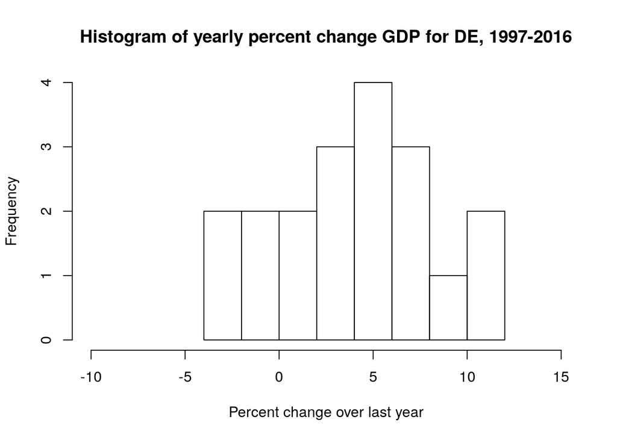

```r
hist(100*GDP_analysis_df$state_gdp, main = "Histogram of yearly percent change GDP for DE, 1997-2016", xlab = "Percent change over last year", xlim = c(-10,15))
```

By loose first inspection, we notice that this variable is relatively well behaved. We can proceed with further investigation and analysis from here.

**Remember:** choose data that is small, easy to clean and readily available. This took me maybe 2-3 hours of writing, analysis and iteration, but from here it is easy. For a nasty dataset, this could be a much longer process.

**For the midterm:** Keep this sort of data cleaning process documented, but this need not be included in the appendix of code. It will be helpful for the final, however, if you keep this on hand and cleanly documented so we can troubleshoot.